# Monthly HIV cohort report

# Report details

Reporting date range: **01 Jan 2009 - 31 Dec 2009**  
Date and time report generated: **17 December 2020, 21:29 UTC**  
Reporting package versions:  
**genericreportr**: 0.0.1.1  
**idreportr**: 0.0.3.9001

Comments or questions to: **his@oca.msf.org**

[output not shown]

Data for **01 Jan 2009 - 31 Dec 2009:**

| Reporting period summary | Figure |
| --- | --- |
| Number of adults ($\geq$ 15 years) initiating treatment | 523 |
| Number of children (< 15 years) initiating treatment | 97 |
| Number of patients lost to follow-up | 169 |
| Number of patients died | 110 |

# Cohort inclusion

## HIV treatment initiations

### Table

|  | Previous 13 months up to 31 December 2009 N (%) | Previous 13 months up to 31 December 2009 Total |
| --- | --- | --- |
| Month: |  | 624 |
| Dec-09 | 177 (28.4%) |  |
| Nov-09 | 41 (6.6%) |  |
| Oct-09 | 37 (5.9%) |  |
| Sep-09 | 43 (6.9%) |  |
| Aug-09 | 41 (6.6%) |  |
| Jul-09 | 28 (4.5%) |  |
| Jun-09 | 43 (6.9%) |  |
| May-09 | 60 (9.6%) |  |
| Apr-09 | 47 (7.5%) |  |
| Mar-09 | 36 (5.8%) |  |
| Feb-09 | 21 (3.4%) |  |
| Jan-09 | 46 (7.4%) |  |
| Dec-08 | 4 (0.6%) |  |

|  | Full programme inclusion up to 31 December 2009 N (%) | Full programme inclusion up to 31 December 2009 Total |
| --- | --- | --- |
| Month: |  | 877 |
| Dec | 205 (23.4%) |  |
| Nov | 62 (7.1%) |  |
| Oct | 60 (6.8%) |  |
| Sep | 59 (6.7%) |  |
| Aug | 60 (6.8%) |  |
| Jul | 49 (5.6%) |  |
| Jun | 60 (6.8%) |  |
| May | 77 (8.8%) |  |
| Apr | 68 (7.8%) |  |
| Mar | 59 (6.7%) |  |
| Feb | 49 (5.6%) |  |
| Jan | 69 (7.9%) |  |

### Monthly initiations

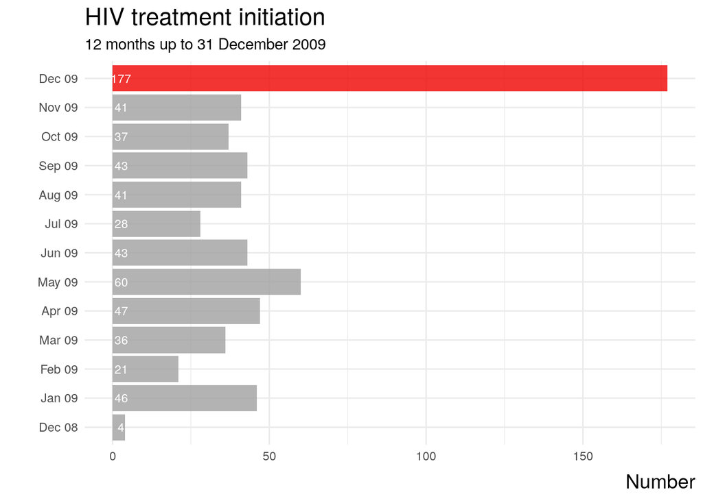

### Quarterly initiations

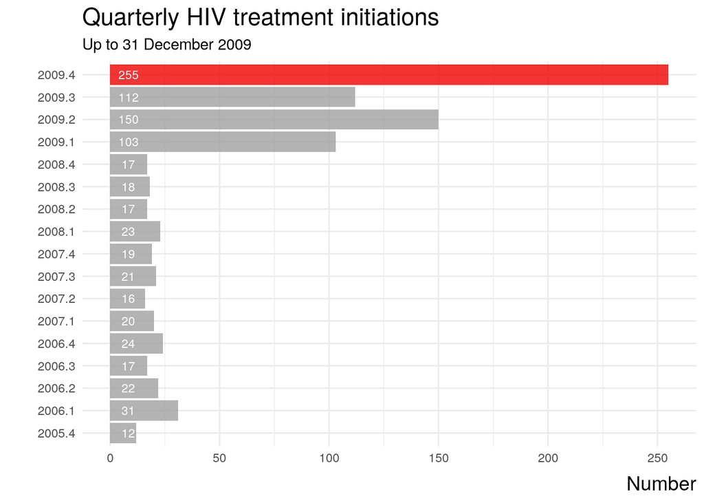

### Definitions

The information in this section aims to summarise programme entry over time. This may be presented by treatment initiation or first consultation. Counts are split into calendar months or quarters and are tabulated and graphically represented. For comparison with more recent information, tables summarising monthly inclusions over the life of a programme are included.

Definition

**Table**  
Summarises the number and percentage of patients included in the cohort by calendar month. Episodes (e.g. treatment initation or pregnancy), rather than individual patients, are counted in this table.

**Monthly & Quarterly plots**  
Monthly and quarterly bar plots visually display programme entry by time period. These counts may be segregated further in some reports (e.g. TB treatment type). This type of plot should quickly illustrate seasonal or temporal changes in programme inclusion

**Key variables**

> Cohort inclusion: Treatment start date

**Key data form**

> Form 2 Treatment Initiation_Début traitement

## Registration characteristics

### Age, gender and BMI

|  | Reporting period N (%) | Reporting period Total | Previous 12 months N (%) | Previous 12 months Total | Full programme N (%) | Full programme Total |
| --- | --- | --- | --- | --- | --- | --- |
| Age: |  | 620 |  | 620 |  | 877 |
| < 15y | 97 (15.6%) |  | 97 (15.6%) |  | 135 (15.4%) |  |
| 15-44y | 179 (28.9%) |  | 179 (28.9%) |  | 245 (27.9%) |  |
| ≥ 45y | 344 (55.5%) |  | 344 (55.5%) |  | 497 (56.7%) |  |
| 'Missing' | 0 (0.0%) |  | 0 (0.0%) |  | 0 (0.0%) |  |
| Gender: |  | 620 |  | 620 |  | 877 |
| Female | 301 (48.5%) |  | 301 (48.5%) |  | 423 (48.2%) |  |
| Male | 296 (47.7%) |  | 296 (47.7%) |  | 424 (48.3%) |  |
| Unknown | 8 (1.3%) |  | 8 (1.3%) |  | 9 (1.0%) |  |
| 'Missing' | 15 (2.4%) |  | 15 (2.4%) |  | 21 (2.4%) |  |
| BMI: |  | 620 |  | 620 |  | 877 |
| ≥ 18.5 | 423 (68.2%) |  | 423 (68.2%) |  | 595 (67.8%) |  |
| < 18.5 | 197 (31.8%) |  | 197 (31.8%) |  | 282 (32.2%) |  |
| 'Missing' | 0 (0.0%) |  | 0 (0.0%) |  | 0 (0.0%) |  |

### Baseline CD4 and WHO Stage

|  | Reporting period N (%) | Reporting period Total | Previous 12 months N (%) | Previous 12 months Total | Full programme N (%) | Full programme Total |
| --- | --- | --- | --- | --- | --- | --- |
| CD4 count: |  | 620 |  | 620 |  | 877 |
| 0-50 | 41 (6.6%) |  | 41 (6.6%) |  | 53 (6.0%) |  |
| 51-200 | 378 (61.0%) |  | 378 (61.0%) |  | 528 (60.2%) |  |
| 201-350 | 194 (31.3%) |  | 194 (31.3%) |  | 284 (32.4%) |  |
| 351-500 | 7 (1.1%) |  | 7 (1.1%) |  | 12 (1.4%) |  |
| ≥ 501 | 0 (0.0%) |  | 0 (0.0%) |  | 0 (0.0%) |  |
| 'Missing' | 0 (0.0%) |  | 0 (0.0%) |  | 0 (0.0%) |  |
| WHO clinical stage: |  | 620 |  | 620 |  | 877 |
| WHO stage 1 | 138 (22.3%) |  | 138 (22.3%) |  | 198 (22.6%) |  |
| WHO stage 2 | 142 (22.9%) |  | 142 (22.9%) |  | 196 (22.3%) |  |
| WHO stage 3 | 140 (22.6%) |  | 140 (22.6%) |  | 193 (22.0%) |  |
| WHO stage 4 | 129 (20.8%) |  | 129 (20.8%) |  | 183 (20.9%) |  |
| Unknown | 59 (9.5%) |  | 59 (9.5%) |  | 89 (10.1%) |  |
| 'Missing' | 12 (1.9%) |  | 12 (1.9%) |  | 18 (2.1%) |  |

### Definitions

This section includes information recorded from patients when they enter the cohort. Relevant variables are presented for each disease. Three reporting periods have been included - the reporting period defined by the user, the 12 months prior to the end of the user-defined reporting period, and the full programme duration.

**Key data forms**

> New patient registration form  
> 1 History HIV_ Antécédents HIV

# Treatment

## Regimens at initiation

### Table

|  | Reporting period N (%) | Reporting period Total | Previous 12 months N (%) | Previous 12 months Total | Full programme N (%) | Full programme Total |
| --- | --- | --- | --- | --- | --- | --- |
| Regimen: |  | 620 |  | 620 |  | 877 |
| TDF/3TC/DTG | 359 (57.9%) |  | 359 (57.9%) |  | 511 (58.3%) |  |
| TDF/3TC/EFV | 115 (18.5%) |  | 115 (18.5%) |  | 156 (17.8%) |  |
| ABC/3TC/DTG | 0 (0.0%) |  | 0 (0.0%) |  | 0 (0.0%) |  |
| ABC/3TC/EFV | 0 (0.0%) |  | 0 (0.0%) |  | 0 (0.0%) |  |
| TDF/3TC/ATV/r | 0 (0.0%) |  | 0 (0.0%) |  | 0 (0.0%) |  |
| AZT/3TC/EFV | 0 (0.0%) |  | 0 (0.0%) |  | 0 (0.0%) |  |
| Other | 55 (8.9%) |  | 55 (8.9%) |  | 78 (8.9%) |  |
| 'Missing' | 91 (14.7%) |  | 91 (14.7%) |  | 132 (15.1%) |  |

### Definitions

This section provides a summary of the treatment regimens prescribed to at initiation to those starting treatment during the defined period.

Definition

**Regimens**  
A selection of the most frequently chosen regimens has been tabulated. Three reporting periods have been included - the reporting period defined by the user, the 12 months prior to the end of the user-defined reporting period, and the full programme duration.

**Key data forms**

> Form 4 Clin Assess Treat HIV_Éval Clin Trait HIV

# Cohort outcome

## Cohort follow-up by time since commencing ART

### Table

|  | 6m FU N (%) | 6m FU Total | 12m FU N (%) | 12m FU Total | 18m FU N (%) | 18m FU Total | 24m FU N (%) | 24m FU Total | 36m FU N (%) | 36m FU Total | 48m FU N (%) | 48m FU Total |
| --- | --- | --- | --- | --- | --- | --- | --- | --- | --- | --- | --- | --- |
| Follow-up: |  | 507 |  | 256 |  | 221 |  | 182 |  | 106 |  | 12 |
| On treatment | 138 (27.2%) |  | 50 (19.5%) |  | 42 (19.0%) |  | 35 (19.2%) |  | 24 (22.6%) |  | 4 (33.3%) |  |
| Returned to care | 53 (10.5%) |  | 33 (12.9%) |  | 30 (13.6%) |  | 26 (14.3%) |  | 16 (15.1%) |  | 2 (16.7%) |  |
| Death | 93 (18.3%) |  | 53 (20.7%) |  | 44 (19.9%) |  | 36 (19.8%) |  | 23 (21.7%) |  | 2 (16.7%) |  |
| LTFU | 174 (34.3%) |  | 98 (38.3%) |  | 85 (38.5%) |  | 70 (38.5%) |  | 33 (31.1%) |  | 4 (33.3%) |  |
| Transfer out | 49 (9.7%) |  | 22 (8.6%) |  | 20 (9.0%) |  | 15 (8.2%) |  | 10 (9.4%) |  | 0 (0.0%) |  |

### Plot

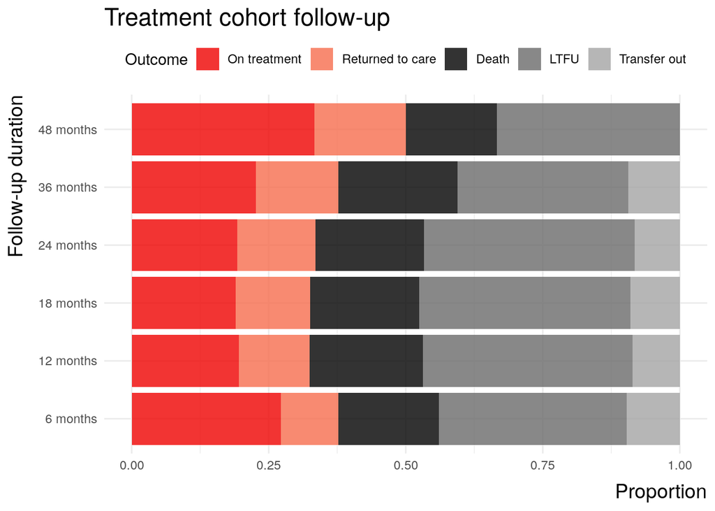

### Definitions

This section collates programme results based on patient follow-up duration

Definition

**Interpretation**  
Each column represents different cohorts of patients defined by when they started ART. The table demonstrates the rate of attrition from the treatment cohort over time - visually represented in the included plot.

**Key data forms**

> Form 2 Treatment initiation Début de traitement  
> Form 6 Status change HIV_Changement du statut VIH

## Viral load

### Table

|  | 6m FU N (%) | 6m FU Total | 12m FU N (%) | 12m FU Total | 18m FU N (%) | 18m FU Total | 24m FU N (%) | 24m FU Total | 36m FU N (%) | 36m FU Total | 48m FU N (%) | 48m FU Total |
| --- | --- | --- | --- | --- | --- | --- | --- | --- | --- | --- | --- | --- |
| HIV VL: |  | 385 |  | 251 |  | 217 |  | 177 |  | 104 |  | 12 |
| Detectable | 114 (29.6%) |  | 78 (31.1%) |  | 61 (28.1%) |  | 49 (27.7%) |  | 30 (28.8%) |  | 3 (25.0%) |  |
| Undetectable | 271 (70.4%) |  | 173 (68.9%) |  | 156 (71.9%) |  | 128 (72.3%) |  | 74 (71.2%) |  | 9 (75.0%) |  |

### Definitions

This section collates programme viral load results based on patient follow-up duration

Definition

**Interpretation**  
Each column represents different cohorts of patients defined by when they started ART. The table demonstrates the durability of HIV treatment and programmatic patient support over time.

**Key data forms**

> Form 2 Treatment initiation Début de traitement  
> Form 3 Lab virology_lab_virologie

## Cohort follow-up by year of ART initiation

### Table

|  | 2005 N (%) | 2005 Total | 2006 N (%) | 2006 Total | 2007 N (%) | 2007 Total |
| --- | --- | --- | --- | --- | --- | --- |
| 1-yr status: |  | 12 |  | 94 |  | 76 |
| On treatment | 4 (33.3%) |  | 20 (21.3%) |  | 11 (14.5%) |  |
| Returned to care | 2 (16.7%) |  | 14 (14.9%) |  | 10 (13.2%) |  |
| Death | 2 (16.7%) |  | 21 (22.3%) |  | 13 (17.1%) |  |
| LTFU | 4 (33.3%) |  | 29 (30.9%) |  | 37 (48.7%) |  |
| Transfer out | 0 (0.0%) |  | 10 (10.6%) |  | 5 (6.6%) |  |
| 'Missing' | 0 (0.0%) |  | 0 (0.0%) |  | 0 (0.0%) |  |

### Plot

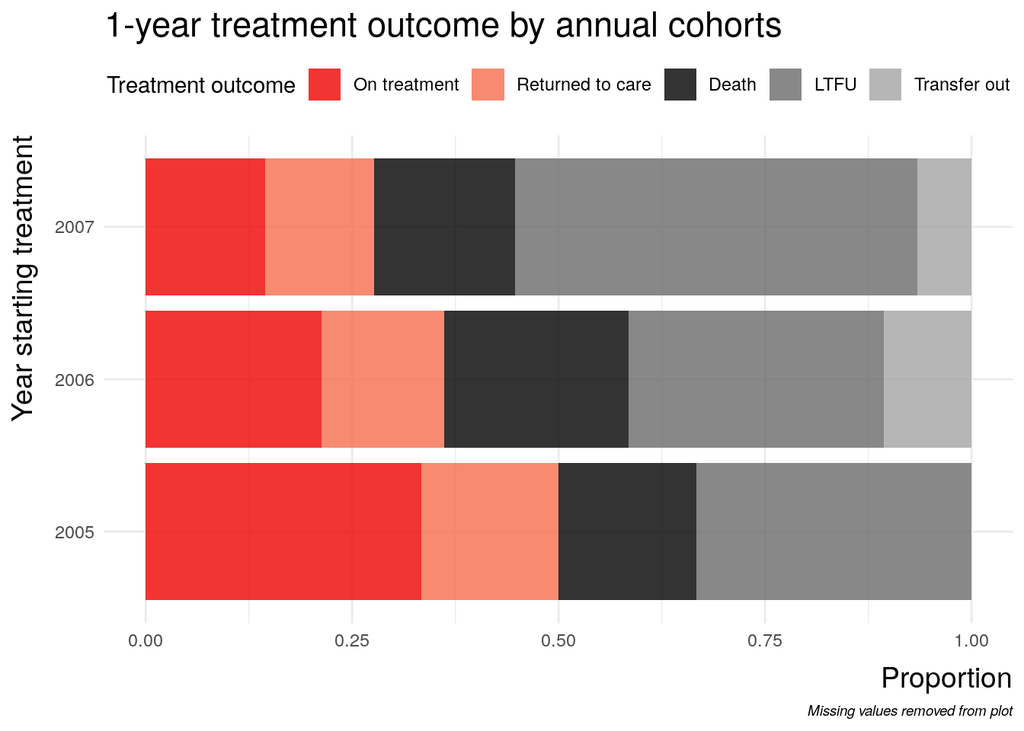

### Definitions

This section presents treatment status after 12 months for cohorts of patients starting treatment in different years.

Definition

**Interpretation**  
Each column represents different cohorts of patients defined by when they started ART. Patients are included into columns depending on the year they started ART - i.e. they represent annual cohorts. Treatment status after receiving 1 year of ART is presented.

**Key data forms**

> Form 2 Treatment initiation Début de traitement  
> Form 6 Status change HIV_Changement du statut VIH